# Introdução ao Método da Máxima Verossimilhança

econometrics

Autor

Washington S. da Silva

Data de Publicação

2 agosto 2026

# Método da Máxima Verossimilhança

O [método da máxima verossimilhança](https://en.wikipedia.org/wiki/Maximum_likelihood_estimation) (*MLE*, do inglês *Maximum Likelihood Estimation*) é amplamente utilizado em estatística para estimar parâmetros de modelos probabilísticos. Ele se baseia na escolha dos valores dos parâmetros que maximizam a função de verossimilhança.

## Função de Verossimilhança

Considere uma amostra aleatória $X_1, X_2, \dots, X_n$, independente e identicamente distribuída, de um modelo com vetor de parâmetros $\boldsymbol{\theta} = (\theta_1, \theta_2, \dots, \theta_k)$. Denotando as observações por $\mathbf{x} = (x_1, x_2, \dots, x_n)$, a função de verossimilhança é:

$$L(\theta; \mathbf{x}) = \prod_{i=1}^n f(x_i \mid \theta)$$

Em modelos contínuos, $f(x_i \mid \theta)$ é uma densidade de probabilidade; em modelos discretos, é uma função de probabilidade. Em ambos os casos, ela é condicionada ao vetor de parâmetros $\theta$.

**Função de Log-Verossimilhança**

A função log-verossimilhança, denotada por $\ell(\theta)$, simplifica a otimização e é expressa por:

$$\ell(\theta; \mathbf{x}) = \log L(\theta; \mathbf{x}) = \sum_{i=1}^n \log f(x_i \mid \theta)$$

## Um problema de otimização

Os estimadores de máxima verossimilhança são obtidos maximizando a função de log-verossimilhança. Para cada componente $\theta_j$ do vetor de parâmetros, as condições de primeira ordem são:

$$\frac{\partial \ell(\theta; \mathbf{x})}{\partial \theta_j} = 0
\quad \text{para } j = 1, \dots, k$$

As soluções dessas equações são pontos candidatos. O máximo deve ser confirmado pelas condições de segunda ordem ou pela comparação dos valores da função de log-verossimilhança, conforme o problema.

## Como Encontrar o Máximo?

**Objetivo:** encontrar os valores de $\boldsymbol{\theta} = (\theta_1, \dots, \theta_k)$ que maximizam $\ell(\boldsymbol{\theta})$.

**Analiticamente:** às vezes, é possível.

- Calcule as derivadas parciais de $\ell(\boldsymbol{\theta})$ em relação a cada parâmetro.
- Iguale cada derivada parcial a zero:

$$\frac{\partial \ell(\boldsymbol{\theta})}{\partial \theta_j} = 0,
\quad j = 1, \dots, k$$

- Resolva o sistema para obter os valores candidatos de $\hat{\boldsymbol{\theta}}$.
- Verifique as condições de **segunda ordem**: para um máximo estrito em um ponto interno, a matriz Hessiana da log-verossimilhança deve ser negativa definida no ponto candidato.

**Numericamente:** na maioria dos problemas reais, usa-se um método de otimização numérico.

O algoritmo procura os valores dos parâmetros que maximizam a função de log-verossimilhança.

## Função de (log-)Verossimilhança

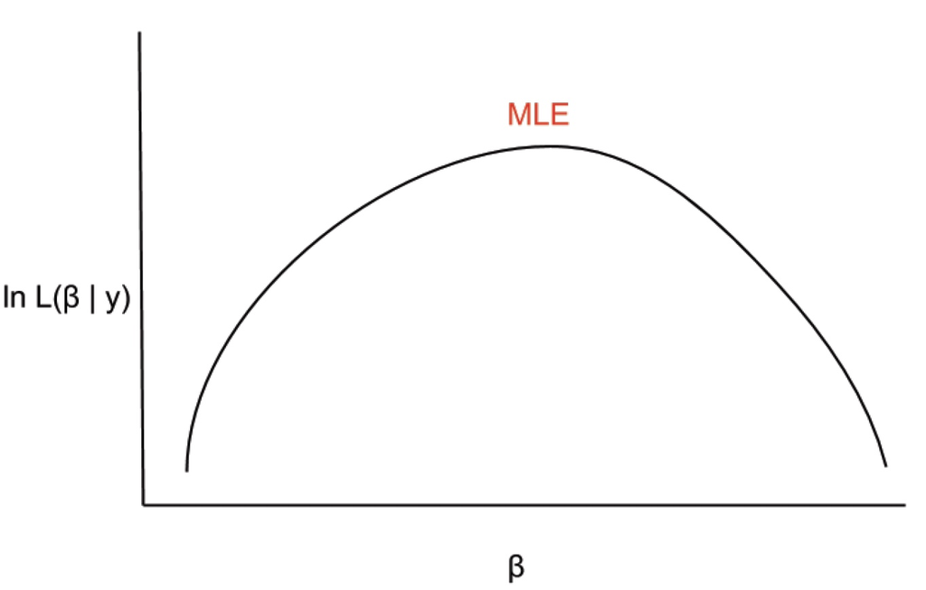

Esta curva resume todas as informações que os dados fornecem  
sobre o vetor de parâmetros $\theta$, assumindo o modelo.

## Estimadores de Máxima Verossimilhança dos Parâmetros de uma Distribuição Normal

Seja $X \sim N(\mu,\sigma^2)$. Sua função densidade de probabilidade (fdp) é:

$$f(x \mid \mu, \sigma^2) = \frac{1}{\sqrt{2\pi\sigma^2}}
\exp\left(-\frac{(x - \mu)^2}{2\sigma^2}\right)$$

Agora, considere $X_1, X_2, \dots, X_n \overset{\text{i.i.d.}}{\sim} \mathcal{N}(\mu, \sigma^2)$. O vetor de parâmetros é $\boldsymbol{\theta} = (\mu, \sigma^2)$. Para os dados observados, a função de verossimilhança é:

$$L(\mu, \sigma^2) = \prod_{i=1}^{n} \frac{1}{\sqrt{2\pi \sigma^2}} \exp\left( -\frac{(x_i - \mu)^2}{2\sigma^2} \right)$$

A **log-verossimilhança** é dada por:

$$\log L(\mu, \sigma^2) = -\frac{n}{2} \log(2\pi \sigma^2) - \frac{1}{2\sigma^2} \sum_{i=1}^n (x_i - \mu)^2$$

Para obter o estimador de máxima verossimilhança de $\mu$, mantemos $\sigma^2$ fixo e derivamos:

$$\begin{aligned}
\frac{\partial}{\partial \mu} \log L(\mu, \sigma^2)
&= \frac{\partial}{\partial \mu} \left[ -\frac{1}{2\sigma^2} \sum_{i=1}^n (x_i - \mu)^2 \right] \\
&= -\frac{1}{2\sigma^2} \cdot \sum_{i=1}^n \frac{\partial}{\partial \mu} (x_i - \mu)^2 \\
&= -\frac{1}{2\sigma^2} \cdot \sum_{i=1}^n [-2(x_i - \mu)] \\
&= \frac{1}{\sigma^2} \sum_{i=1}^n (x_i - \mu)
\end{aligned}$$

Igualando a zero e resolvendo:

$$\frac{1}{\sigma^2} \sum_{i=1}^n (x_i - \mu) = 0
\;\Rightarrow\;
\sum_{i=1}^n (x_i - \mu) = 0
\;\Rightarrow\;
n\bar{x} - n\mu = 0
\;\Rightarrow\;
\boxed{\widehat{\mu} = \bar{x} = \frac{1}{n} \sum_{i=1}^n x_i}$$

Esse estimador é **não-viesado**:

$$E(\widehat{\mu}) = E(\bar{x}) = \mu$$

e sua variância e desvio-padrão são:

$$\mathrm{Var}(\bar{x}) = \frac{\sigma^2}{n}, \quad \mathrm{DP}(\bar{x}) = \frac{\sigma}{\sqrt{n}}$$

Para encontrar o EMV de $\sigma^2$, derivamos a log-verossimilhança em relação a $\sigma^2$, mantendo $\mu = \bar{x}$:

$$\begin{aligned}
\frac{\partial}{\partial \sigma^2} \log L(\mu, \sigma^2)
&= -\frac{n}{2} \cdot \frac{1}{\sigma^2} + \frac{1}{2\sigma^4} \sum_{i=1}^n (x_i - \mu)^2 \\
&= -\frac{n}{2\sigma^2} + \frac{1}{2\sigma^4} \sum_{i=1}^n (x_i - \bar{x})^2
\end{aligned}$$

Igualando a zero:

$$-\frac{n}{2\sigma^2} + \frac{1}{2\sigma^4} \sum_{i=1}^n (x_i - \bar{x})^2 = 0$$

Multiplicando ambos os lados por $2\sigma^4$:

$$-n\sigma^2 + \sum_{i=1}^n (x_i - \bar{x})^2 = 0
\;\Rightarrow\;
\boxed{\widehat{\sigma}^2 = \frac{1}{n} \sum_{i=1}^n (x_i - \bar{x})^2}$$